# Lesson 17: Inference for One Proportion

Preparation

- Word Document
- PDF Document

## Solutions

**Please note that the steps show rounded numbers, but that the final answers to the problems are calculated without rounding.**

Problem

Part

Solution

1

-

$\hat{p} = \frac{x}{n}$  
x = number of successes  
n = number of trials.

2

-

$\hat{p} \pm z^* \sqrt{\frac{\hat{p}(1-\hat{p})}{n}}$

3

-

$n \hat{p} \geq 10$  
$n(1 - \hat{p}) \geq 10$

4

-

$n = (\frac{z^*}{2m})^2$

5

-

$z = \frac{\hat{p}-p}{\sqrt{\frac{p(1-p)}{n}}}$

6

-

$np \geq 10$  
$n(1 - p) \geq 10$

7

A

$\hat{p}=\frac{x}{n}=\frac{684}{1006}=0.6799$

7

B

$n \hat{p} \geq 10$ -> $1006* 0.6799\geq 10$ -> $684 \geq 10$  
$n(1 - \hat{p}) \geq 10$ -> $1006(1-0.6799) \geq 10$ -> $322 \geq 10$  
The requirements are met.

7

C

$1.96 * \sqrt{\frac{\hat{p}(1-\hat{p})}{n}} = 1.96 * \sqrt{\frac{0.6799(1-0.6799)}{1006}}=0.0288$

7

D

$\hat{p} \pm \text{margin of error}$ -> $0.6799 \pm 0.0288$ -> (0.6511, 0.7087)  
We are 95% confident that the true population mean, *p*, is between 0.6511 and 0.7087.

7

E

$n = (\frac{z^*}{2m})^2 = (\frac{1.96}{2\times0.015})^2 = 4268.4444$ -> $4269$

8

A

$H_0: p = 0.6$  
$H_a: p > 0.6$

8

B

$z = \frac{0.6799-0.6}{\sqrt{\frac{0.6(1-0.6}{1006}}} = 5.174$

8

C

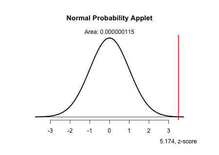

p = 0

8

D

We reject the null hypothesis

8

E

We have sufficient evidence to conclude that the true proportion of students that have been in a car accident within the last 5 years is greater than 0.6.